# Taller 1: introducción a R

## 3.4 Funciones gráficas básicas

Otra gran ventaja de R son sus capacidades gráficas. Los gráficos se pueden exportar en diferentes formatos (pdf, eps, jpg, etc.). Para ver una selección de gráficos realizados con `R` puede ejecutarse un programa demostración mediante la siguiente instrucción:

```r
# demo("graphics") # Esta comentada para no hacer muy grande el documento
```

La función básica y quizás la más usada para generar gráficas de series o datos es `plot()`. Previamente se ha de definir el vector de los datos que serán representados en el eje de las ordenadas (eje y) y si es necesario, el vector de los datos del eje de las abscisas (eje x). Como atributo se especifica el tipo de gráfica (puntos, líneas, ambos, etc). Un ejemplo sencillo es el siguiente:

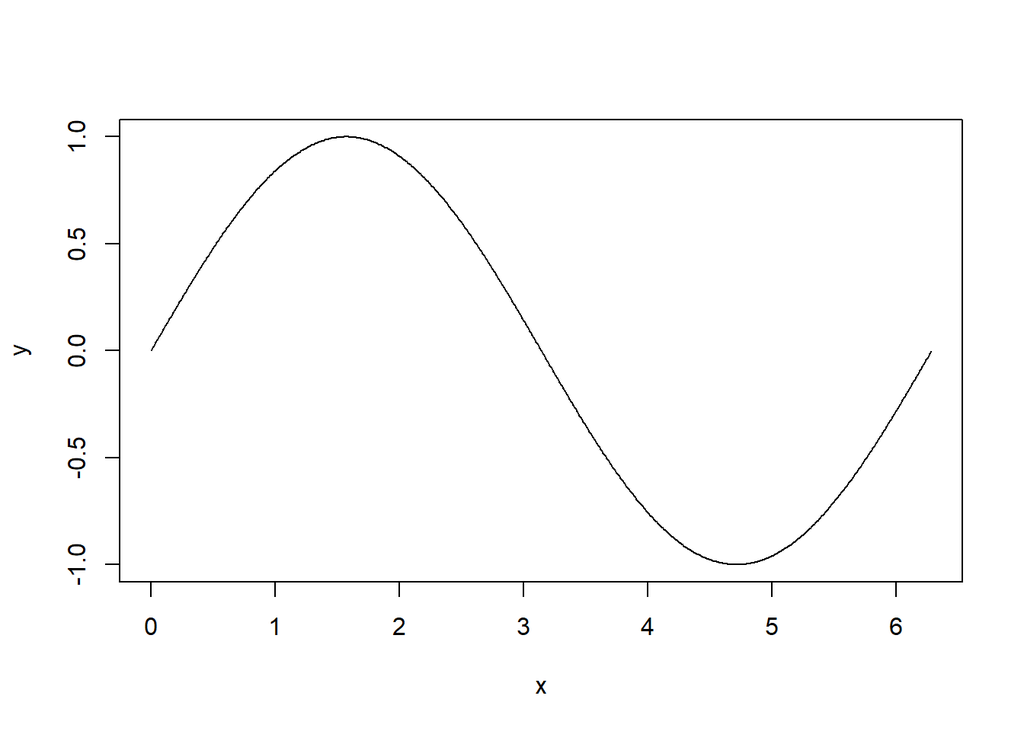

```r
x=seq(0,2*pi,0.01)
y=sin(x)
plot(x,y,type='l')
```

También es frecuente el uso de la función `lines()`, por ejemplo.

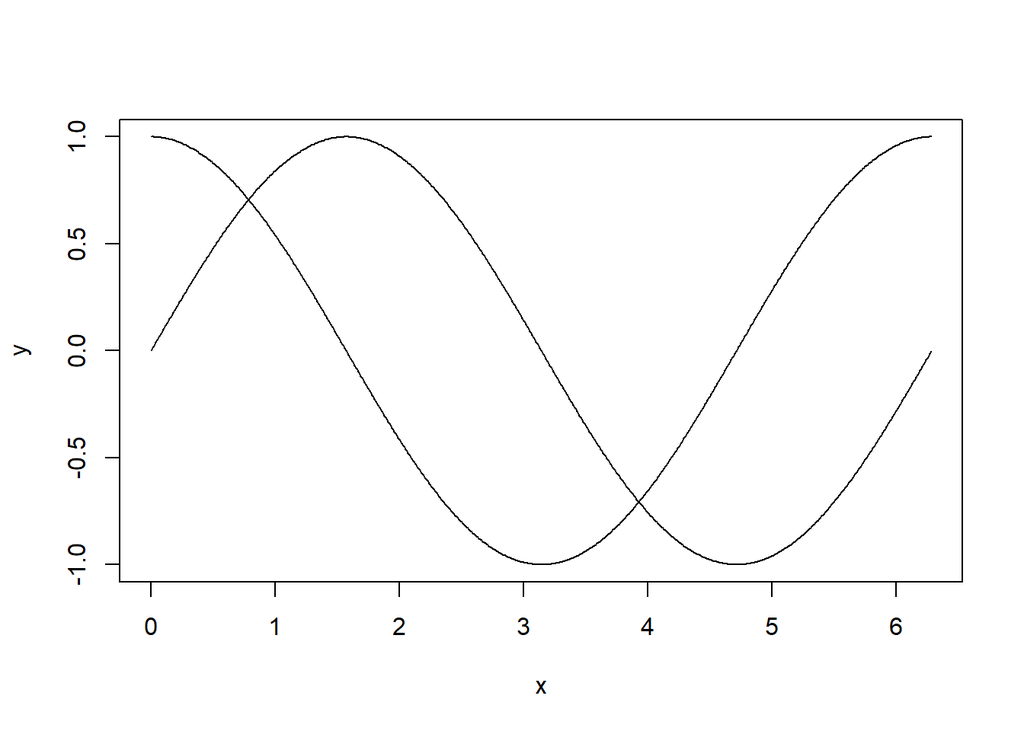

```r
x=seq(0,2*pi,0.01)
z=cos(x)
plot(x,y, type='l')
lines(x,z)
```

Para generar múltiples gráficas en una sola ventana se puede hacer de la siguiente forma:

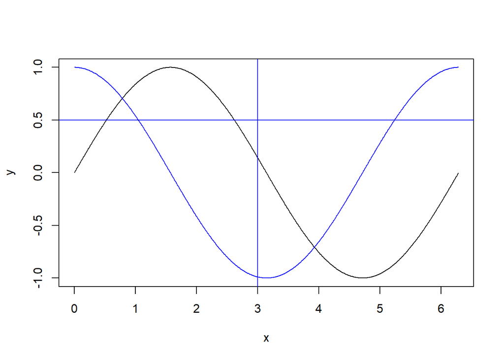

```r
x=seq(0,2*pi,0.01)
y=sin(x); z=cos(x)
plot(x,y,type='l')
par(col='blue')
lines(x,z)
abline(h=0.5); abline(v=3)
```

## 3.5 Guardando y recuperando sesión

Cuando se termina una sesión de R, tenemos la opción de guardar el espacio de trabajo (workspace) o el historial (history). El espacio de trabajo incluyen todos los objetos definidos por el usuario, estos objetos se van almacenando en memoria intermedia mientras se está trabajando, pero se elimina al cerrar una sesión. Por otra parte, el historial es el conjunto de todos los comandos que se han utilizado en la sesión. Si se quiere guardar un objeto en concreto (por ejemplo, el vector x) en el fichero MyData.Rdata, se utiliza la siguiente instrucción:

```r
save(x,file='MyData.Rdata')
```

Para guardar todos los objetos existentes en el espacio de trabajo:

```r
save.image('MyData.Rdata')
```

Recuperar todos los objetos previamente guardados en un fichero:

```r
load('MyData.Rdata')
```

Si se desea guardar o cargar un historial de comandos:

```r
savehistory('MyData.RHistory')
loadhistory('MyData.RHistory')
```

**Tips**

- Para limpiar la consola, usamos `Ctrl+L`
- Para visualizar los objetos almacenados en el espacio de trabajo, `ls()`
- Para eliminar un objeto, `rm(name)`
- Para eliminar todos los objetos, `rm(list=ls())`
- Para visualizar el directorio de trabajo (working directory), usamos `getwd()`
- Para ajustar el directorio de trabajo al especificado, `setwd("midirectorio")`

3.6 Scripts o guiones, la forma de organizar la sesión

Hasta ahora se ha trabajado directamente en la consola de R o Rstudio (o en el notebook de markdown) y se ha definido cómo se guardan todas las instrucciones que se han ejecutado (correctas y erróneas). Sin embargo, esta forma de guardar una sesión no es la más aconsejable. Se recomienda, que el trabajo que se realice en cualquier entorno de programación sin ser R la excepción, se guarde en forma de scripts o guiones. Un script no es más que un documento d texto plano que contiene el conjunto de instrucciones o código que se desea ejecutar. En él, se pueden registra comentarios de cada instrucción o de un conjunto de ellas. De esta manera, nuestro código queda guardado de una forma organizada y clara para su entendimiento en una futura sesión, un ejemplo se puede ver en la Figura 3. Para crear un nuevo script, nos dirigimos a la barra de menú con el ratón, se selecciona `Ficheros`, `Nuevo fichero` y finalmente `R script`. También mediante el teclado, pulsando simultáneamente `Ctrl+Shift+N`. Est documento se puede editar, modificar, guardar y ejecutar (todas las instrucciones, parte de ellas o las línea deseadas).

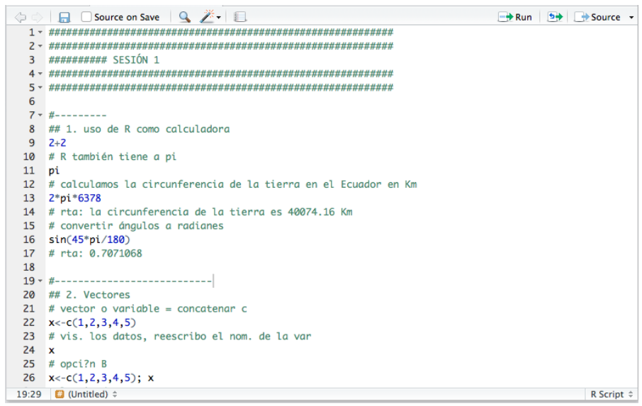

Figura 3. Script de Rstudio.

## 3.7 Material Extra

En los siguientes sitios web, se pueden encontrar los ficheros necesarios para la instalación del R, el R-Commander y el Rstudio, además varios tutoriales que ayudarán a la ampliación de la información presentada en esta guía de prácticas.

- https://www.r-project.org/
- https://www.rstudio.com/products/rstudio/features/
- http://www.rcommander.com/
- http://www.tutorialr.es/es/index.html
- https://es.wikipedia.org/wiki/R_(lenguaje_de_programaci%C3%B3n)

# 4. Ejercicios

#### Ejercicio 4.1

Dado un vector x = (x1, x2, . . . , xn), crear un vector y que contenga los índices de x, es decir, y = (1, 2, . . . , n). Hazlo con un ejemplo determinado.

#### Ejercicio 4.2

Introducir el vector x<-c(2, 5, 120, 5, 8, 11). Supongamos que me he equivocado y he olvidado el número 7 entre el 5 y el 8 (índices 4 y 5 resp.). ¿Cómo arreglarlo? También he olvidado el último número: después del 11, viene un 3. Finalmente, resulta que el valor 120 es un error tipográfico, en realidad es un 12. Llevar a cabo las correcciones pertinentes…

#### Ejercicio 4.3

Generar dos vectores x e y tal que x contenga los valores de 0 a 5 con un incremento de 0.01, y tal que y sea igual a sen(x). A continuación, realizar la gráfica de y en función de x con la instrucción plot(x,y).

#### Ejercicio 4.4

Generar un vector que contenga 12 valores, los primeros 4 siendo igual a 0.5, los 4 siguientes a 1.5, y los 4 últimos a 3.

#### Ejercicio 4.5

Introducir los siguientes vectores: x<-c(1, 3, 5, 7, 9), y<-c(2, 3, 5, 7, 11, 13). Ejecuta las siguientes instrucciones y explica que realiza cada una:

- x+1
- y*2
- c<-(length(x),length(y))
- x+y
- sum(x>5)
- sum(x[x>5])
- sum(x[x>5 | x>3])
- y[y>7]

#### Ejercicio 4.6

Encontrar como calcular la media de un vector $x$ sin utilizar la función mean

#### Ejercicio 4.7

Encontrar una manera alternativa (no utilizar sd) de calcular la varianza de un vector x, utilizando la fórmula: $var(x)=\bar{x^2}-(\bar{x})^2$

#### Ejercicio 4.8

A lo largo de un año, los importes de las facturas mensuales del celular han sido: 23, 33, 25, 45, 10, 28, 39, 27, 15, 38, 34, 29. Escriba un script en R en el que se cree una tabla de datos con meses y cargos. El script debe responder automáticamente las siguientes preguntas, incluso si cambia cualquier valor.

1. ¿Cúanto se ha gastado en total en el año?
2. ¿En qué mes se ha gastado menos dinero? ¿Cuánto ha sido?
3. ¿En qué mes se ha gastado más dinero?¿Cuánto ha sido?
4. ¿En cúales meses se ha gastado más que el promedio

#### Ejercicio 4.9

Un geyser es un nacimiento de agua hirviente que de vez en cuando se vuelve inestable y expulsa agua y vapor. El geyser Old Faithful en el parque de Yellowstone en Wyoming es probablemente el más famoso del mundo. Los visitantes del parque se acercan al emplazamiento del geyser intentando no tener que esperar demasiado para verlo estallar. Los servicios del Parque colocan un cartel donde se anuncia la próxima erupción. Es por lo tanto de interés estudiar los intervalos de tiempo entre dos erupciones conjuntamente con la duración de cada erupción. En el fichero `geyser.txt` están los datos correspondientes a la duración de 222 erupciones, así como el intervalo de tiempo hasta la siguiente erupción, durante los meses de agosto 1978 y agosto 1979. Las unidades de medición son ms. - Importar los datos, realizar una exploración gráfica, ¿qué características presentan los datos? - ¿Puedes identificar dos grupos de erupciones? Crea una variable grupo, que indique a qué grupo se asigna cada erupción.